# 01 - Entity extraction with regex

## Entity extraction and its relations

The package {networds} provides a set of tools to extract entities and relations from text. The first of this tools uses one of the simples form: by using the rule based approach. It contains a rule based extraction algorithm and a rule based relation extraction algorithm. Another similar package is textnets, from Chris Bail. It capture the proper names using UDpipe, plot word networks and calculates the centrality/betweeness of words in the network. To extract entities based on Part of speech tagging, see other functions of this package,

The functions of {networds} do not work so well like the NER, but we think that, in some situations, they can be better job than traditional joining unigram, bigrams, trigrams and so on. Because it is a rule based approach, it is very simple to use, need less dependencies and runs also fast (or maybe less slower). It will also requires a lot of post-cleaning, but you have the absolute control over which words are extracted and what words are rejected.

In Natural Language Processing, to find proper names or terms that frequently appears together is called “collocation”, e.g., to find “United Kingdom”. You can learn more what is collocation and its statistical details and r function in this [article](https://sigil.r-forge.r-project.org/materials/04_collocation_analysis.pdf), and it is also possible to functions like [`quanteda.textstats::textstat_collocations()`](https://quanteda.io/reference/textstat_collocations.html), [`TextForecast::get_collocations()`](https://cran.r-project.org/web/packages/TextForecast/) to identify them, but it also will require a lot of data cleaning, specially if you want is proper names.

## How it works?

The function captures all words that:

- begins with uppercase,
- followed by other uppercases, lowercase or numbers, without white space
- it can contain symbols like `_`, `-` or `.`. In this way, words like “Covid-19” are captured.
- the user can specify a connector, like “of”or “of the” so, words like “United States of America” are also captured

In languages such as English and Portuguese, it extracts proper names. In German, it also extracts nouns. There is some trade-off, of course. It will capture a lot of undesired words and will demand posterior cleaning, like:  
- It does not contain any sort of built-in classification.  
- “Obama Chief of Staff Rahm Emanuel” will be captured as one entity, what is not wrong et al, but maybe not what was expect.

## The downsides

It will not capture:

- entities that begin with lowercase.
- it does not delves with words ambiguity. For example, is “WHO” referring to question or World Health Organization? Washington is a person or a place?

To overthrow this problemas, networds has a set of other functions that works with Part of Speech tagging and Named Entity Recognition. If the problems enumerated are a big problem to your case, take a look at the next session “Extract entity co-ocurrences with POS”.

## Conclusion

In my experience, the approach of this section using regex works better to certain types of text than others. Very well formatted text, like Books, formal articles can be a good option that works well with this function. Text from social media, because it lacks formalities of the language and have a lot of typos, lacking uppercase sometimes, or written all in uppercase, this approach will not work so well.

## Using networds: extracting entities with regex

After installing the package (see Readme), load it:

```r
library(networds)
```

So, let’s extract some proper names from a simple text:

```r
"John Does lives in New York in United States of America." |> extract_entity()
```

```
#> [1] "John Does"                "New York"
#> [3] "United States of America"
```

Or it is possible to use other languages, specifying the parameter `connectors` using the function `connectors(lang)`. Checking the connectors:

```r
connectors("eng")
```

```
#> [1] "of"     "of the"
```

```r
# or you can also use for english, to get the same result:
connectors("en")
```

```
#> [1] "of"     "of the"
```

```r
# For portuguese
connectors("pt")
```

```
#> [1] "da"  "das" "de"  "do"  "dos"
```

```r
# to get the same result:
connectors("port")
```

```
#> [1] "da"  "das" "de"  "do"  "dos"
```

```r
# by default, the functions uses the parameter "misc". meaning "miscellaneous".
connectors("misc")
```

```
#> [1] "of"     "the"    "of the" "von"    "van"    "del"
```

```r
"João Ninguém mora em São José do Rio Preto. Ele esteve antes em Sergipe" |>
  extract_entity(connect = connectors("pt"))
```

```
#> [1] "João Ninguém"          "São José do Rio Preto" "Ele"
#> [4] "Sergipe"
```

```r
vonNeumann_txt <- "John von Neumann (/vɒn ˈnɔɪmən/ von NOY-mən; Hungarian: Neumann János Lajos [ˈnɒjmɒn ˈjaːnoʃ ˈlɒjoʃ]; December 28, 1903 – February 8, 1957) was a Hungarian and American mathematician, physicist, computer scientist and engineer"
vonNeumann_txt |> extract_entity()
```

```
#> [1] "John von Neumann"    "NOY-"                "Hungarian"
#> [4] "Neumann János Lajos" "December"            "February"
#> [7] "Hungarian"           "American"
```

## Extracting a graph

It is possible to extract a graph from the extracted entities. First, happens the tokenization by sentence or paragraph. Than, the entities are extracted using `extract_entity()`. Than a data frame with the co-occurrence of words in sentences or paragraph is build.

```r
vonNeumann_txt |> extract_graph()
```

```
#> Tokenizing by sentences
#> # A tibble: 27 × 2
#>    n1               n2
#>    <chr>            <chr>
#>  1 John von Neumann NOY-
#>  2 John von Neumann Hungarian
#>  3 John von Neumann Neumann János Lajos
#>  4 John von Neumann December
#>  5 John von Neumann February
#>  6 John von Neumann Hungarian
#>  7 John von Neumann American
#>  8 NOY-             Hungarian
#>  9 NOY-             Neumann János Lajos
#> 10 NOY-             December
#> # ℹ 17 more rows
```

One of the parameters is `sw` that means “stopwords”. It is possible to add a vector stopwords.

```r
my_sw <- c(stopwords::stopwords(
  language = "en",
  source = "snowball", simplify = TRUE
), "lol")

vonNeumann_txt |> extract_graph(sw = my_sw)
```

```
#> Tokenizing by sentences
#> # A tibble: 27 × 2
#>    n1               n2
#>    <chr>            <chr>
#>  1 John von Neumann NOY-
#>  2 John von Neumann Hungarian
#>  3 John von Neumann Neumann János Lajos
#>  4 John von Neumann December
#>  5 John von Neumann February
#>  6 John von Neumann Hungarian
#>  7 John von Neumann American
#>  8 NOY-             Hungarian
#>  9 NOY-             Neumann János Lajos
#> 10 NOY-             December
#> # ℹ 17 more rows
```

This process can take a while to run if the text/corpus is big. So, if you are interested only in some words, so first of all, filter the sentences/paragraphs with the desired words, and after that, extract the graph. Seeing another example, extracting from a Wikipedia article:

```r
page <- "https://en.wikipedia.org/wiki/GNU_General_Public_License" |> rvest::read_html()
```

```r
text <- page |>
  rvest::html_nodes("p") |>
  rvest::html_text()

# looking at the scraped text:
text[1:2] # seeing the head of the text
```

```
#> [1] "\n\n"
#> [2] "The GNU General Public Licenses (GNU GPL or simply GPL) are a series of widely used free software licenses, or copyleft licenses, that guarantee end users the freedoms to run, study, share, and modify the software.[7] The GPL was the first copyleft license for general use. It was originally …
```

And now extracting the graphs:

```r
g <- text |> extract_graph(sw = my_sw)
```

```
#> Tokenizing by sentences
```

```r
g
```

```
#> # A tibble: 3,239 × 2
#>    n1                              n2
#>    <chr>                           <chr>
#>  1 The GNU General Public Licenses GNU GPL
#>  2 The GNU General Public Licenses GPL
#>  3 The GNU General Public Licenses The GPL
#>  4 The GNU General Public Licenses Richard Stallman
#>  5 The GNU General Public Licenses Free Software Foundation
#>  6 The GNU General Public Licenses FSF
#>  7 The GNU General Public Licenses GNU Project
#>  8 The GNU General Public Licenses Free Software Definition
#>  9 The GNU General Public Licenses GPL
#> 10 The GNU General Public Licenses Lesser General Public License
#> # ℹ 3,229 more rows
```

```r
g_N <- g |> dplyr::count(n1, n2, sort = T)
g_N
```

```
#> # A tibble: 2,100 × 3
#>    n1           n2              n
#>    <chr>        <chr>       <int>
#>  1 GPLv3        GPLv2          24
#>  2 Artifex      Hancom         19
#>  3 Ghostscript  Hancom         19
#>  4 Linux        GPL            16
#>  5 GPL          FSF            14
#>  6 GPL-licensed GPL            14
#>  7 GPL          GPLv3          13
#>  8 Artifex      Ghostscript    12
#>  9 However      GPL            12
#> 10 FSF          GPL            11
#> # ℹ 2,090 more rows
```

To plot the wordcloud network it is necessary two parameters: the original text and the dataframe/tibble as returned by `dplyr::count()`, with three columns: node 1, node 2 and the weight/frequency.

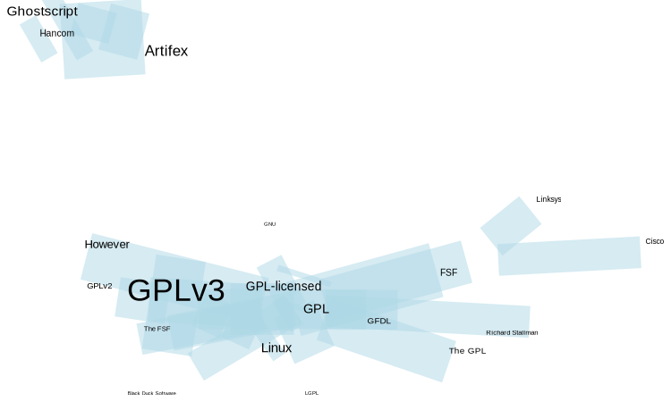

```r
net_wordcloud(text, g_N)
```

There are different information in the graph:

- The size of words and compound words means the individual frequency of each word/compound word
- The thickness of the links indicates how often the pair occur together.

We opted to use this approach of the two parameters of data frame with weights, as well as with the original text because plotting such networks as a matter of readability, often requires to select only the most frequent. A word individual frequency is not necessarily correlated with it’s frequency in graphs, so the function calculates the individual frequency of the word. Looking at the frequency dataframe, the user may want to strip some graphs, and then plot it.

This function uses {[ggraph](https://ggraph.data-imaginist.com/reference/)} and ggplot. So, you can change some ggplot or add another ones *a posteriori*.

To plot an interactive graph, it is possible to use {[networkD3](https://christophergandrud.github.io/networkD3/)}:

```r
g_N |>
  head(100) |> # to reduce the amount of nodes and edges in the graph
  networkD3::simpleNetwork(
    height = "10px", width = "30px",
    linkDistance = 50,
    fontSize = 16
  )
```

[interactive chart not shown]

Another text example.

```r
page <- "https://en.wikipedia.org/wiki/Hurricane_Milton" |> rvest::read_html()
```

```r
text <- page |>
  rvest::html_nodes("p") |>
  rvest::html_text()

text[1:2] # seeing the head of the tex
```

```
#> [1] "\n\n\n"
#> [2] "Hurricane Milton was an extremely powerful and destructive tropical cyclone which became the second-most intense Atlantic hurricane ever recorded over the Gulf of Mexico, behind only Hurricane Rita in 2005. Milton made landfall on the west coast of the U.S. state of Florida, less than two we…
```

```r
g <- text |> extract_graph(sw = my_sw)
```

```
#> Tokenizing by sentences
```

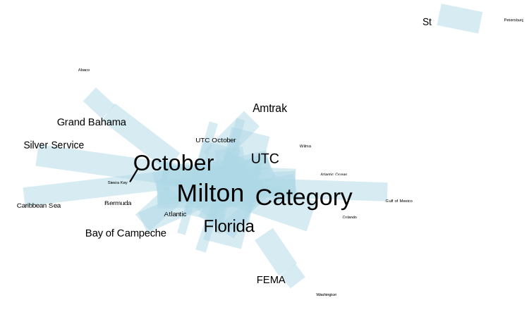

```r
# option 1: use counting the edge frequency
g_N <- g |> dplyr::count(n1, n2, sort = T)
# option 2: use count_graph function, same results
g_N <- g |> count_graph()

net_wordcloud(text, g_N, head_n = 50)
```

To plot an interactive graph, it is possible to use {networkD3}:

```r
g_N |>
  head(100) |> # to reduce the amount of nodes and edges in the graph
  networkD3::simpleNetwork(
    height = "10px", width = "30px",
    linkDistance = 50,
    fontSize = 16
  )
```

[interactive chart not shown]